# Capstone-2 data Analysis

Bernard Banda

2024-11-28

## Project Summary

Using publicly available data from sources like the EPA Smart Location Database, FBI Crime Data Explorer, and U.S. Census Bureau, this project combines statistical and spatial analysis techniques to identify key predictors of mental health burden. The findings will inform targeted public health interventions and urban planning strategies to improve mental health outcomes and resource allocation within high-need neighborhoods.

## Data Sources and Variables

#### **Mental Health Burden (Outcome Variable)**

The number of mental health service requests serves as a proxy for mental health burden. These requests are aggregated from the 211 Counts database, which documents calls for assistance related to substance abuse, crisis intervention, suicide prevention, and other mental health needs. The data is reported at the zip code level and reflects the total mental health-related requests during the year 2020. This dataset is maintained by the Health Communication Research Laboratory at Washington University in St. Louis.

#### **Control Variables**

Additional variables are included to account for confounding factors that may influence mental health burden:

- **Below Poverty Level Percentage**: The proportion of residents living below the poverty line, sourced from the U.S. Census Bureau (ACS 2020).
- **Insured Percentage**: The percentage of residents with health insurance coverage, sourced from the ACS 2020.
- **Housing Occupancy Percentage**: The proportion of occupied housing units, indicating residential stability, sourced from the ACS 2020.
- **Weighted Education Score**: The percentage of residents with at least a high school diploma or higher education, derived from ACS educational attainment data (2020).
- **Population Density**: Measured as the number of residents per square mile, calculated from the ACS population estimates (2020).
- **Population** : Number of residents in a zipcode from the ACS population estimates (2020).

### 1. **Installing and Loading Required Libraries**

Installing all necessary packages for data manipulation, statistical modeling, spatial analysis, and visualization for this analysis/project.

```r
# Loading required packages for statistical, spatial, and data analysis
# Ensures all necessary tools for modeling, visualization, and exporting results are available
# Using pacman for streamlined installation and loading, improving reproducibility and ease of use
if (!requireNamespace("pacman", quietly = TRUE)) install.packages("pacman")
pacman::p_load(
  MASS, car, spdep, ggplot2, sf, dplyr, tidyverse, sandwich, lmtest,
  SMPracticals, writexl, broom, stargazer,ggmap, DiagrammeR, MICE, kableExtra
)
```

## Data Preparation

### **1. Load Data on 211 Mental Health Requests and Covariates**

Importing the dataset with 211 data and associated covariates / variables needed for analysis.

```r
# Data Import and Preparation
mh_data2020 <- read.csv('Clean_rev_data_capstone_clean.csv', header = TRUE, stringsAsFactors = FALSE)
```

### **2. Cleaning 211 and Covariates Dataset**

Cleaning the dataset ensures data integrity by removing missing values and converting relevant variables into factors, preparing the data for accurate statistical and spatial analysis.

```r
# Remove rows with missing values to ensure complete cases
      #mh_data2020_clean <- na.omit(mh_data2020)

# Examine the structure of the cleaned dataset to verify data types
      #str(mh_data2020_clean)

# Convert relevant categorical variables to factors for analysis
      mh_data2020_clean <- mh_data2020 %>%
        mutate(
          stlCity = as.factor(stlCity),
          County = as.factor(County),
          cityName = as.factor(cityName),
          ZCTA = as.factor(ZCTA),
          Rurality = as.factor(Rurality)
        )
```

### 2b. Addressing missing data

```r
# Load the library
library(mice)
```

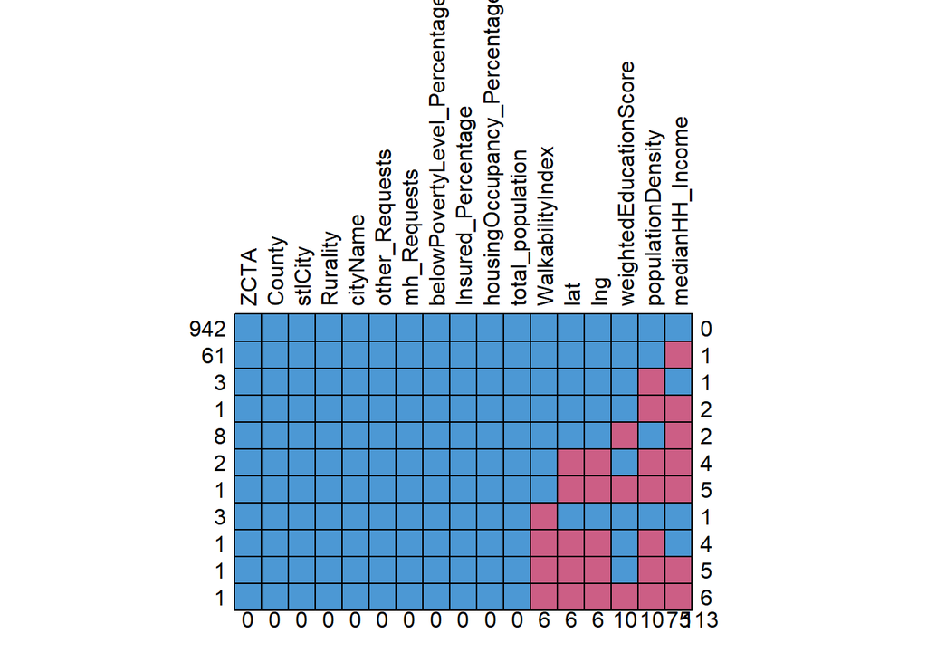

```
##     ZCTA County stlCity Rurality cityName other_Requests mh_Requests
## 942    1      1       1        1        1              1           1
## 61     1      1       1        1        1              1           1
## 3      1      1       1        1        1              1           1
## 1      1      1       1        1        1              1           1
## 8      1      1       1        1        1              1           1
## 2      1      1       1        1        1              1           1
## 1      1      1       1        1        1              1           1
## 3      1      1       1        1        1              1           1
## 1      1      1       1        1        1              1           1
## 1      1      1       1        1        1              1           1
## 1      1      1       1        1        1              1           1
##        0      0       0        0        0              0           0
##     belowPovertyLevel_Percentage Insured_Percentage housingOccupancy_Percentage
## 942                            1                  1                           1
```

[output cut: 37 more lines]

```r
# Check missing data patterns
md.pattern(mh_data2020, rotate.names = TRUE)
```

**Interpretation:**

As shown in the figure above, the dataset contains 1,024 rows (observations), of which 942 rows are complete, with no missing values across any variables. However, a subset of 82 rows has missing data, with the highest frequency of missingness observed in variables such as weightedEducationScore, populationDensity, and medianHH_Income. Other variables remain mostly intact with little to no missingness.

This pattern of missing data indicates that while the majority of the dataset is complete, specific variables with missing values, particularly medianHH_Income, may impact the analysis. Given that the missing data is limited to 82 rows, its impact on statistical power is minimal. If the missingness mechanism is likely Missing Completely at Random (MCAR) or Missing at Random (MAR), multiple imputation techniques can be employed to address the missing data without introducing bias. Alternatively, listwise deletion may be a viable option due to the relatively small proportion of missing data.

### 2c. Handling Missing Values Listwise Deletion

```r
#Drop observations with missing data on income_level
  ex1 <- mh_data2020_clean %>%
  drop_na(WalkabilityIndex) # 1018

  #Drop observations with missing data on housing_instability
  ex2 <- ex1 %>%
  drop_na(lat ) # 1015

   #Drop observations with missing data on employment_status
  ex3 <- ex2 %>%
  drop_na(weightedEducationScore) # 1007

  #Drop observations with missing data on health_insurance_status
  ex4 <- ex3 %>%
  drop_na(Insured_Percentage) # 1007

  #Drop observations with missing data on health_insurance_status
  ex5 <- ex4 %>%
  drop_na(populationDensity ) # 1003

  #Drop observations with missing data on health_insurance_status
  ex6 <- ex5 %>%
  drop_na(medianHH_Income) # 942

  #assigning ex5 dataframe a proper name
  mh_data2020_clean <- ex6
```

### 2d. Visualizing the data management in a Figure 1

```r
grViz("
digraph flowchart {

  # Set global node properties
  node [fontname = Helvetica, shape = rectangle, fontsize = 12, width = 4, height = 0.6]

  # Define nodes with concise labels
  node1 [label = 'Starting records: n = 1024']
  node2 [label = 'Excluding missing WalkabilityIndex: n = 1,018']
  node3 [label = 'Excluding missing coordinates: n = 1,015']
  node4 [label = 'Excluding missing weighted Education Score: n = 1,007']
  node5 [label = 'Excluding missing population Density: n = 1,003']
  node6 [label = 'Excluding missing median HH Income: n = 942']

  # Create edges to show flow
  node1 -> node2 -> node3 -> node4 -> node5 -> node6
}
")
```

[interactive chart not shown]

**Interpretation**

After a Listwise case deletion of missing data, the final dataset had 942 complete cases for analysis

### **3. Load Spatial Data or ZCTA Polygons**

Importing the ZCTA (Zip Code Tabulation Areas) shapefile provides geographic boundaries essential for spatial analysis, linking zip codes to neighborhood-level characteristics.

```r
# Load the ZCTA shapefile and verify the data structure
zcta_boundaries <- st_read("MO_TIGER_5_Digit_Zip_Code_Tabulation_Areas.shp", quiet = TRUE)
```

### 4. **Cleaning the Shapefile Dataset**

Select relevant variables from the shapefile dataset, ensuring only necessary columns are retained for spatial analysis.

```r
# Select relevant variables from the ZCTA boundaries dataset
zcta_boundaries_clean <- zcta_boundaries %>%
  dplyr::select(FID, ZCTA5CE20, GEOID20, GEOIDFQ20, INTPTLAT20, INTPTLON20,
                Shape__Are, Shape__Len, geometry)
```

### **5. Merging the 211 and Shapefiles by ZCTA (Zipcode)**

```r
# Merge 211 data with zcta_shapefiles
mh_data2020_clean <- zcta_boundaries_clean %>%
  right_join(mh_data2020_clean, by = c("ZCTA5CE20" = "ZCTA"))  # Adjust column names as needed
```

## **Descriptive Analysis**

### **1. Descriptive Table**

Summarizing the data in a descriptive Table

```r
# Load the necessary package for creating descriptive tables
library(table1)
# Assign variable labels for better readability in the table
label(mh_data2020_clean$mh_Requests) <- "Mental Health Requests"
label(mh_data2020_clean$WalkabilityIndex) <- "Walkability Index"
label(mh_data2020_clean$medianHH_Income) <- "Median Household Income ($)"
label(mh_data2020_clean$belowPovertyLevel_Percentage) <- "Below Poverty Level (%)"
label(mh_data2020_clean$Insured_Percentage) <- "Insured Population (%)"
label(mh_data2020_clean$housingOccupancy_Percentage) <- "Housing Occupancy (%)"
label(mh_data2020_clean$weightedEducationScore) <- "Weighted Education Score"
label(mh_data2020_clean$populationDensity) <- "Population Density (per sq. mile)"
label(mh_data2020_clean$Rurality) <- "Rural or Urban Classification"

# Generate descriptive Table 1
table1(~ mh_Requests + WalkabilityIndex + medianHH_Income + belowPovertyLevel_Percentage +
         Insured_Percentage + housingOccupancy_Percentage +
         weightedEducationScore + populationDensity | Rurality,
       data = mh_data2020_clean)
```

|  | Rural (N=724) | Urban (N=218) | Overall (N=942) |
| --- | --- | --- | --- |
| Mental Health Requests |  |  |  |
| Mean (SD) | 1.37 (6.18) | 8.66 (15.1) | 3.06 (9.54) |
| Median [Min, Max] | 0 [0, 89.0] | 2.00 [0, 84.0] | 0 [0, 89.0] |
| Walkability Index |  |  |  |
| Mean (SD) | 5.12 (1.88) | 8.07 (3.89) | 5.80 (2.78) |
| Median [Min, Max] | 4.74 [2.44, 16.1] | 6.24 [2.44, 18.9] | 5.00 [2.44, 18.9] |
| Median Household Income ($) |  |  |  |
| Mean (SD) | 51000 (17300) | 63100 (22500) | 53800 (19300) |
| Median [Min, Max] | 49100 [10700, 165000] | 61500 [8620, 161000] | 50900 [8620, 165000] |
| Below Poverty Level (%) |  |  |  |
| Mean (SD) | 15.2 (9.91) | 12.5 (10.4) | 14.6 (10.1) |
| Median [Min, Max] | 14.0 [0, 88.0] | 10.0 [0, 83.0] | 13.0 [0, 88.0] |
| Insured Population (%) |  |  |  |
| Mean (SD) | 88.2 (8.95) | 90.5 (6.40) | 88.7 (8.48) |
| Median [Min, Max] | 90.0 [28.0, 100] | 92.0 [66.0, 100] | 90.0 [28.0, 100] |
| Housing Occupancy (%) |  |  |  |
| Mean (SD) | 78.6 (13.5) | 88.8 (9.48) | 81.0 (13.4) |
| Median [Min, Max] | 81.0 [25.0, 100] | 91.0 [38.0, 100] | 84.0 [25.0, 100] |
| Weighted Education Score |  |  |  |
| Mean (SD) | 2.47 (0.295) | 2.75 (0.326) | 2.54 (0.324) |
| Median [Min, Max] | 2.46 [1.35, 3.65] | 2.73 [1.98, 3.74] | 2.50 [1.35, 3.74] |
| Population Density (per sq. mile) |  |  |  |
| Mean (SD) | 209 (715) | 1390 (2050) | 482 (1270) |
| Median [Min, Max] | 21.8 [2.30, 7500] | 472 [12.0, 11500] | 30.1 [2.30, 11500] |

**Interpretation:**

As indicated in Table 1 above, urban areas exhibit significantly higher mental health requests (mean: 8.66) compared to rural areas (mean: 1.37), alongside greater walkability and household income. Rural areas face higher poverty rates (15.2% vs. 12.5%) and lower housing occupancy (78.6% vs. 88.8%), reflecting socioeconomic and infrastructure disparities. Urban areas have a denser population (mean: 1,390 per sq. mile) and higher educational attainment (weighted score: 2.75 vs. 2.47). These findings highlight urban-rural differences in resources, accessibility, and mental health service demand.

### **2. Distribution of Walkability Scores (Histogram)**

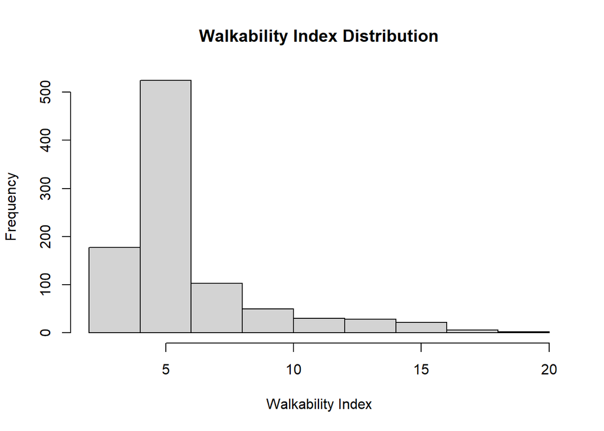

```r
hist(mh_data2020_clean$WalkabilityIndex, main="Walkability Index Distribution", xlab="Walkability Index")
```

**Interpretation**

The histogram shows a right-skewed distribution of the Walkability Index, with most neighborhoods having low walkability scores concentrated between 2.5 and 6.5. Few neighborhoods exhibit high walkability, with the frequency declining beyond a score of 10. This highlights disparities in walkable infrastructure.

### **3. Relationship Between Walkability and Median Household Income Across Urban and Rural Areas**

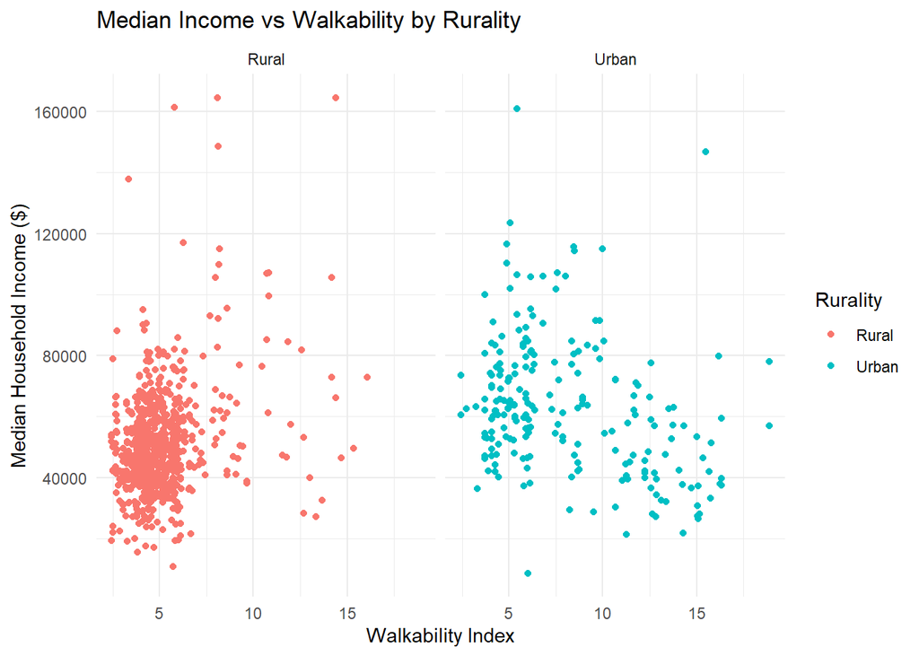

```r
ggplot(mh_data2020_clean, aes(x = WalkabilityIndex, y = medianHH_Income, color = Rurality)) +
  geom_point() +
  facet_wrap(~ Rurality) +
  labs(
    title = "Median Income vs Walkability by Rurality",
    x = "Walkability Index",
    y = "Median Household Income ($)"
  ) +
  theme_minimal()
```

**Interpretation**:

## Statistical Analysis

### **1. Base Model - Poisson Regression**

Mental health service requests (outcome variable) represents count data, a **Poisson regression model** is an appropriate starting point, as it models counts with a log link and adjusts for population size using an offset. This will allow us to estimate the association between neighborhood characteristics and mental health service requests. After fitting the model, overdispersion will be asessed to ensure the variance assumptions of the Poisson model are met.

```r
# Adjust population for log(0) cases (adding a small constant if necessary)

# Create the offset term as the log of the adjusted population
# Add a small constant to population to avoid log(0) if necessary
mh_data2020_clean$population_adj <- ifelse(mh_data2020_clean$total_population == 0, 1, mh_data2020_clean$total_population)

# Create the offset term
mh_data2020_clean$offset_term = log(mh_data2020_clean$population_adj)
```

```r
# Fit the Poisson regression model
model_poisson <- glm(mh_Requests ~ WalkabilityIndex + medianHH_Income +
                       Insured_Percentage +housingOccupancy_Percentage + weightedEducationScore + populationDensity,
                       family = poisson(link = 'log'),
                       offset = offset_term,
                       data = mh_data2020_clean)

# Display the summary of the Poisson model
summary(model_poisson)
```

```
##
## Call:
## glm(formula = mh_Requests ~ WalkabilityIndex + medianHH_Income +
##     Insured_Percentage + housingOccupancy_Percentage + weightedEducationScore +
##     populationDensity, family = poisson(link = "log"), data = mh_data2020_clean,
##     offset = offset_term)
##
## Coefficients:
##                               Estimate Std. Error z value Pr(>|z|)
## (Intercept)                 -9.049e+00  4.111e-01 -22.014  < 2e-16 ***
## WalkabilityIndex             1.935e-01  6.964e-03  27.782  < 2e-16 ***
## medianHH_Income             -8.645e-06  1.710e-06  -5.055 4.30e-07 ***
## Insured_Percentage           4.247e-02  5.488e-03   7.740 9.96e-15 ***
## housingOccupancy_Percentage -6.722e-03  2.491e-03  -2.698  0.00697 **
## weightedEducationScore      -1.319e+00  1.115e-01 -11.830  < 2e-16 ***
## populationDensity            1.893e-04  1.033e-05  18.335  < 2e-16 ***
## ---
## Signif. codes:  0 '***' 0.001 '**' 0.01 '*' 0.05 '.' 0.1 ' ' 1
##
## (Dispersion parameter for poisson family taken to be 1)
##
##     Null deviance: 5422.6  on 941  degrees of freedom
## Residual deviance: 2109.5  on 935  degrees of freedom
## AIC: 3035
##
## Number of Fisher Scoring iterations: 6
```

```r
#Show Odds and CIs
tidy(model_poisson, exponentiate = TRUE, conf.int = TRUE)
```

```
## # A tibble: 7 × 7
##   term                 estimate std.error statistic   p.value conf.low conf.high
##   <chr>                   <dbl>     <dbl>     <dbl>     <dbl>    <dbl>     <dbl>
## 1 (Intercept)          0.000118   4.11e-1    -22.0  2.11e-107  5.20e-5  0.000261
## 2 WalkabilityIndex     1.21       6.96e-3     27.8  7.14e-170  1.20e+0  1.23
## 3 medianHH_Income      1.00       1.71e-6     -5.06 4.30e-  7  1.00e+0  1.00
## 4 Insured_Percentage   1.04       5.49e-3      7.74 9.96e- 15  1.03e+0  1.05
## 5 housingOccupancy_Pe… 0.993      2.49e-3     -2.70 6.97e-  3  9.89e-1  0.998
## 6 weightedEducationSc… 0.267      1.12e-1    -11.8  2.72e- 32  2.15e-1  0.332
## 7 populationDensity    1.00       1.03e-5     18.3  4.33e- 75  1.00e+0  1.00
```

### 1.1 Checking for overdispersion

```r
# Calculate variance-to-mean ratio
overdispersion_test <- sum(residuals(model_poisson, type = "pearson")^2) / model_poisson$df.residual
print(paste("Variance-to-Mean Ratio (Overdispersion Test):", overdispersion_test))
```

```
## [1] "Variance-to-Mean Ratio (Overdispersion Test): 2.91426491519345"
```

#### Interpretation:

Since the variance to mean ratio greater than 1, there is overdispersion, and we need to switch to a Negative Binomial model.

### 2. Adjusted Model - Negative Binomial Regression Model

```r
# Fit the Negative Binomial regression model using the offset within the formula
nb_model <- glm.nb(
  mh_Requests ~ WalkabilityIndex + medianHH_Income +
    Insured_Percentage + housingOccupancy_Percentage +
    weightedEducationScore + populationDensity +
    offset(offset_term),  # Include offset in the formula
  data = mh_data2020_clean
)
```

```r
# Display the summary of the model
summary(nb_model)
```

```
##
## Call:
## glm.nb(formula = mh_Requests ~ WalkabilityIndex + medianHH_Income +
##     Insured_Percentage + housingOccupancy_Percentage + weightedEducationScore +
##     populationDensity + offset(offset_term), data = mh_data2020_clean,
##     init.theta = 0.808328107, link = log)
##
## Coefficients:
##                               Estimate Std. Error z value Pr(>|z|)
## (Intercept)                 -8.926e+00  9.992e-01  -8.933   <2e-16 ***
## WalkabilityIndex             2.277e-01  2.624e-02   8.677   <2e-16 ***
## medianHH_Income             -2.464e-06  4.563e-06  -0.540   0.5892
## Insured_Percentage           2.597e-03  1.204e-02   0.216   0.8292
## housingOccupancy_Percentage  6.522e-03  6.562e-03   0.994   0.3203
## weightedEducationScore      -7.064e-01  3.400e-01  -2.078   0.0377 *
## populationDensity            1.641e-04  5.312e-05   3.090   0.0020 **
## ---
## Signif. codes:  0 '***' 0.001 '**' 0.01 '*' 0.05 '.' 0.1 ' ' 1
##
## (Dispersion parameter for Negative Binomial(0.8083) family taken to be 1)
##
##     Null deviance: 1039.01  on 941  degrees of freedom
## Residual deviance:  595.04  on 935  degrees of freedom
## AIC: 2098.3
##
## Number of Fisher Scoring iterations: 1
##
##
##               Theta:  0.8083
##           Std. Err.:  0.0936
##
##  2 x log-likelihood:  -2082.2990
```

```r
#Show Odds and CIs
tidy(nb_model, exponentiate = TRUE, conf.int = TRUE)
```

```
## # A tibble: 7 × 7
##   term                  estimate std.error statistic  p.value conf.low conf.high
##   <chr>                    <dbl>     <dbl>     <dbl>    <dbl>    <dbl>     <dbl>
## 1 (Intercept)           0.000133   9.99e-1    -8.93  4.14e-19  1.64e-5  0.000964
## 2 WalkabilityIndex      1.26       2.62e-2     8.68  4.06e-18  1.19e+0  1.32
## 3 medianHH_Income       1.00       4.56e-6    -0.540 5.89e- 1  1.00e+0  1.00
## 4 Insured_Percentage    1.00       1.20e-2     0.216 8.29e- 1  9.79e-1  1.03
## 5 housingOccupancy_Per… 1.01       6.56e-3     0.994 3.20e- 1  9.94e-1  1.02
## 6 weightedEducationSco… 0.493      3.40e-1    -2.08  3.77e- 2  2.52e-1  0.981
## 7 populationDensity     1.00       5.31e-5     3.09  2.00e- 3  1.00e+0  1.00
```

**Interpretation**:

The Negative Binomial regression highlights significant predictors of mental health service requests. Walkability Index is positively associated with requests (estimate: 0.2277, p < 0.001), while education has a negative association (estimate: -0.7064, p = 0.038). Population density also shows a positive relationship (estimate: 0.00016, p = 0.002). Other variables, including median income and insured percentage, were not significant. The model fits well, with a reduction in deviance (from 1039.01 to 595.04) and an AIC of 2098.3, confirming it accounts for overdispersion.

### **2.1 Likelihood ratio test (LRT) to compare the Poisson model and Negative Binomial model**

```r
lr_test_results <- lrtest(model_poisson, nb_model)

# Print results with a clear explanation
cat("Likelihood Ratio Test Results:\n")
```

```
## Likelihood Ratio Test Results:
```

```r
print(lr_test_results)
```

```
## Likelihood ratio test
##
## Model 1: mh_Requests ~ WalkabilityIndex + medianHH_Income + Insured_Percentage +
##     housingOccupancy_Percentage + weightedEducationScore + populationDensity
## Model 2: mh_Requests ~ WalkabilityIndex + medianHH_Income + Insured_Percentage +
##     housingOccupancy_Percentage + weightedEducationScore + populationDensity +
##     offset(offset_term)
##   #Df  LogLik Df  Chisq Pr(>Chisq)
## 1   7 -1510.5
## 2   8 -1041.2  1 938.73  < 2.2e-16 ***
## ---
## Signif. codes:  0 '***' 0.001 '**' 0.01 '*' 0.05 '.' 0.1 ' ' 1
```

```r
# Interpret the results
if (lr_test_results$`Pr(>Chisq)`[2] < 0.05) {
  cat("\nThe test suggests that the Negative Binomial model is a better fit than the Poisson model (p < 0.05).\n")
} else {
  cat("\nThe test does not suggest a significant improvement with the Negative Binomial model (p >= 0.05).\n")
}
```

```
##
## The test suggests that the Negative Binomial model is a better fit than the Poisson model (p < 0.05).
```

**Interpretation**:

The Likelihood Ratio Test results indicate that the Negative Binomial model provides a significantly better fit to the data compared to the Poisson model (p < 0.001). The large Chi-squared statistic (938.73) reflects a substantial improvement in model fit, suggesting that the Negative Binomial model accounts for overdispersion in the count data.

### 2.2 Check for spatial Autocorrelation using the Moran’s I test

```r
# Load required libraries
library(spdep)
library(sf)

# Ensure your dataset is an sf object
mh_data2020_clean_sf <- st_as_sf(mh_data2020_clean)

# Create a spatial weights object using Queen’s Contiguity
nb <- poly2nb(mh_data2020_clean_sf, queen = TRUE)  # Change queen to FALSE for Rook's contiguity
listw <- nb2listw(nb, style = "W")            # Convert to weights list object
```

```r
# Extract residuals from the negative binomial model
residuals_nb <- residuals(nb_model, type = "pearson")

# Moran's I test
moran_test <- moran.test(residuals_nb, listw)

# Print results
print(moran_test)
```

```
##
##  Moran I test under randomisation
##
## data:  residuals_nb
## weights: listw
##
## Moran I statistic standard deviate = 3.8462, p-value = 5.998e-05
## alternative hypothesis: greater
## sample estimates:
## Moran I statistic       Expectation          Variance
##      0.0778320694     -0.0010626993      0.0004207572
```

**Interpretation**:

## 2.3 Exploring spatial Autocorrelation using the Delaunay Triangulation chart

```r
# Create a spatial neighbors object using Delaunay triangulation
coords <- st_coordinates(st_centroid(mh_data2020_clean_sf))  # Get centroids of polygons
```

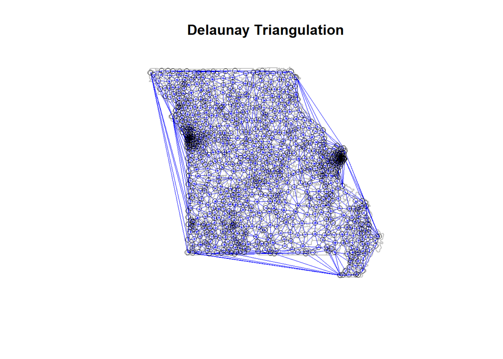

```r
triangulation <- tri2nb(coords)  # Create Delaunay triangulation

# Convert the triangulation into a spatial weights matrix
listw <- nb2listw(triangulation, style = "B", zero.policy = TRUE)

# Plot the spatial connections
plot(st_geometry(mh_data2020_clean_sf), border = "gray", main = "Delaunay Triangulation")
plot(triangulation, coords, add = TRUE, col = "blue", lwd = 0.5)
```

**Interpretation:**

This Delaunay Triangulation chart visualizes the spatial connectivity of neighborhoods in Missouri, constructed using centroids of neighborhood polygons from the dataset. The chart illustrates spatial connectivity among Missouri neighborhoods, with dense clusters around urban centers like St. Louis and Kansas City. These dense areas suggest a lack of spatial independence, as nearby neighborhoods are likely to share similar characteristics or influence each other. This supports the results from the Moran’s I test above sugggesting spatial autocorrelation in variables. As such we will conduct spatial adjustments using the spatial lag to ensure accurate analysis. Also, the analysis will further be stratified by urban and rural areas.

### 3. Model 3 - Spatial Negative Binomial Regresssion Model

#### Calculating a spatial Lag Term

A spatial lag term represents the weighted average of the dependent variable in neighboring areas.It is calculated using the spatial weights matrix.

```r
# Step 1: Create a spatial weights matrix
coords <- cbind(mh_data2020_clean_sf$lng, mh_data2020_clean_sf$lat)  # Ensure numeric and non-missing values
nb <- knn2nb(knearneigh(coords, k = 4))                             # Create neighbor list
lw <- nb2listw(nb, style = "W")                                     # Convert to spatial weights matrix

# Step 2: Compute the spatial lag term
mh_data2020_clean_sf$spatial_lag <- lag.listw(lw, mh_data2020_clean_sf$mh_Requests, zero.policy = TRUE)
```

### 3.1 Fit a Negative Binomial Model with Spatial Lag

```r
#Fit the Negative Binomial model with the spatial lag term to address the spatial] autocorrelation

nb_model_with_spatial_lag <- glm.nb(
  mh_Requests ~ WalkabilityIndex + medianHH_Income + WalkabilityIndex*Rurality +
   Insured_Percentage +
    housingOccupancy_Percentage + weightedEducationScore + populationDensity + spatial_lag,
  data = mh_data2020_clean_sf
)


#Summarize the NB model
summary(nb_model_with_spatial_lag)
```

```
##
## Call:
## glm.nb(formula = mh_Requests ~ WalkabilityIndex + medianHH_Income +
##     WalkabilityIndex * Rurality + Insured_Percentage + housingOccupancy_Percentage +
##     weightedEducationScore + populationDensity + spatial_lag,
##     data = mh_data2020_clean_sf, init.theta = 0.3169795793, link = log)
##
## Coefficients:
##                                  Estimate Std. Error z value Pr(>|z|)
## (Intercept)                    -7.278e+00  1.087e+00  -6.698 2.11e-11 ***
## WalkabilityIndex                2.501e-01  5.123e-02   4.882 1.05e-06 ***
## medianHH_Income                -1.460e-05  5.401e-06  -2.702 0.006886 **
## RuralityUrban                   1.208e+00  4.330e-01   2.789 0.005290 **
## Insured_Percentage             -9.023e-03  1.154e-02  -0.782 0.434424
## housingOccupancy_Percentage     4.074e-02  7.502e-03   5.430 5.63e-08 ***
## weightedEducationScore          1.346e+00  3.816e-01   3.526 0.000421 ***
## populationDensity               6.420e-05  8.322e-05   0.771 0.440414
## spatial_lag                     6.364e-02  1.172e-02   5.428 5.68e-08 ***
## WalkabilityIndex:RuralityUrban -1.018e-01  5.583e-02  -1.823 0.068271 .
## ---
## Signif. codes:  0 '***' 0.001 '**' 0.01 '*' 0.05 '.' 0.1 ' ' 1
##
## (Dispersion parameter for Negative Binomial(0.317) family taken to be 1)
##
##     Null deviance: 1352.31  on 941  degrees of freedom
## Residual deviance:  618.38  on 932  degrees of freedom
## AIC: 2400
##
## Number of Fisher Scoring iterations: 1
##
##
##               Theta:  0.3170
##           Std. Err.:  0.0317
##
##  2 x log-likelihood:  -2378.0330
```

```r
#Show Odds and CIs
tidy(nb_model_with_spatial_lag, exponentiate = TRUE, conf.int = TRUE)
```

```
## # A tibble: 10 × 7
##    term                 estimate std.error statistic  p.value conf.low conf.high
##    <chr>                   <dbl>     <dbl>     <dbl>    <dbl>    <dbl>     <dbl>
##  1 (Intercept)          0.000691   1.09e+0    -6.70  2.11e-11  5.51e-5   0.00795
##  2 WalkabilityIndex     1.28       5.12e-2     4.88  1.05e- 6  1.15e+0   1.44
##  3 medianHH_Income      1.00       5.40e-6    -2.70  6.89e- 3  1.00e+0   1.00
##  4 RuralityUrban        3.35       4.33e-1     2.79  5.29e- 3  1.37e+0   8.38
##  5 Insured_Percentage   0.991      1.15e-2    -0.782 4.34e- 1  9.64e-1   1.02
##  6 housingOccupancy_Pe… 1.04       7.50e-3     5.43  5.63e- 8  1.03e+0   1.06
##  7 weightedEducationSc… 3.84       3.82e-1     3.53  4.21e- 4  1.65e+0   9.15
##  8 populationDensity    1.00       8.32e-5     0.771 4.40e- 1  1.00e+0   1.00
##  9 spatial_lag          1.07       1.17e-2     5.43  5.68e- 8  1.04e+0   1.10
## 10 WalkabilityIndex:Ru… 0.903      5.58e-2    -1.82  6.83e- 2  7.98e-1   1.02
```

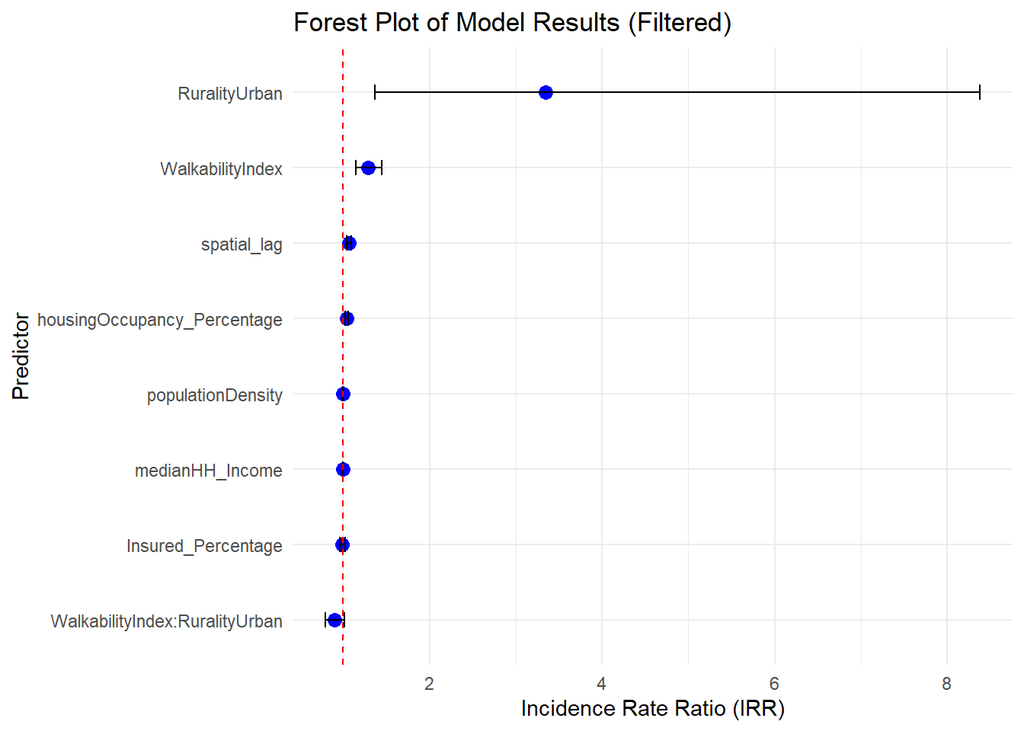

```r
# plot a forest plot t show the results

# Extract model summary as a tidy dataframe
model_summary <- tidy(nb_model_with_spatial_lag, exponentiate = TRUE, conf.int = TRUE)

# Filter out 'weightedEducationScore'
filtered_summary <- model_summary %>%
  filter(term != "weightedEducationScore", term != "(Intercept)")

# Create a forest plot
ggplot(filtered_summary, aes(x = reorder(term, estimate), y = estimate)) +
  geom_point(size = 3, color = "blue") +
  geom_errorbar(aes(ymin = conf.low, ymax = conf.high), width = 0.2) +
  coord_flip() +
  xlab("Predictor") +
  ylab("Incidence Rate Ratio (IRR)") +
  ggtitle("Forest Plot of Model Results (Filtered)") +
  geom_hline(yintercept = 1, linetype = "dashed", color = "red") +
  theme_minimal()
```

### Diagnostics for the Spatial NB Model

### 3.2 Moran’s I Test for Residuals

Check whether the residuals still exhibit spatial autocorrelation.

```r
#Check for residual spatial autocorrelation
moran_test <- moran.test(residuals(nb_model_with_spatial_lag, type = "pearson"), listw, zero.policy = TRUE)
print(moran_test)
```

```
##
##  Moran I test under randomisation
##
## data:  residuals(nb_model_with_spatial_lag, type = "pearson")
## weights: listw
##
## Moran I statistic standard deviate = 1.8384, p-value = 0.033
## alternative hypothesis: greater
## sample estimates:
## Moran I statistic       Expectation          Variance
##      0.0312873211     -0.0010626993      0.0003096458
```

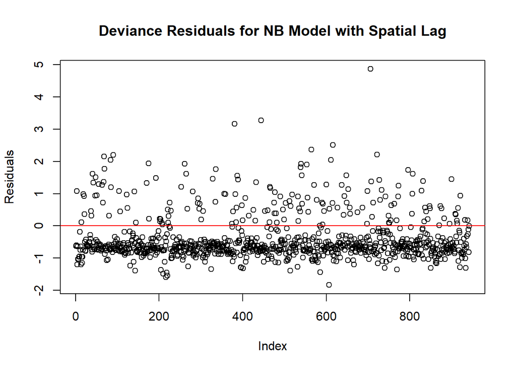

```r
# Residual plot for nb_model_with_spatial_lag
plot(residuals(nb_model_with_spatial_lag, type = "deviance"),
     main = "Deviance Residuals for NB Model with Spatial Lag",
     ylab = "Residuals", xlab = "Index", pch = 1)
abline(h = 0, col = "red")
```

**Interpretation**:

### 3.3 Checking for better fit

```r
# Compare AIC values
aic_values <- AIC(nb_model, nb_model_with_spatial_lag)
print(aic_values)
```

```
##                           df      AIC
## nb_model                   8 2098.299
## nb_model_with_spatial_lag 11 2400.033
```

```r
# Perform a Likelihood Ratio Test (LRT)
lr_test <- lrtest(nb_model, nb_model_with_spatial_lag)
print(lr_test)
```

```
## Likelihood ratio test
##
## Model 1: mh_Requests ~ WalkabilityIndex + medianHH_Income + Insured_Percentage +
##     housingOccupancy_Percentage + weightedEducationScore + populationDensity +
##     offset(offset_term)
## Model 2: mh_Requests ~ WalkabilityIndex + medianHH_Income + WalkabilityIndex *
##     Rurality + Insured_Percentage + housingOccupancy_Percentage +
##     weightedEducationScore + populationDensity + spatial_lag
##   #Df  LogLik Df  Chisq Pr(>Chisq)
## 1   8 -1041.2
## 2  11 -1189.0  3 295.73  < 2.2e-16 ***
## ---
## Signif. codes:  0 '***' 0.001 '**' 0.01 '*' 0.05 '.' 0.1 ' ' 1
```

```r
# Interpretation of the better fit
if (lr_test$`Pr(>Chisq)`[2] < 0.05) {
  cat("\nThe model with the spatial lag (nb_model_with_spatial_lag) provides a significantly better fit than the original model (nb_model) based on LRT (p < 0.05).\n")
} else {
  cat("\nThe original model (nb_model) provides a comparable or better fit than the spatial lag model (nb_model_with_spatial_lag) based on LRT (p >= 0.05).\n")
}
```

[output not shown]

**Interpretation**:

### 3.4 Check for multicollinearity

```r
# VIF for nb_model_with_spatial_lag
library(car)  # For VIF calculation
vif_values <- vif(nb_model_with_spatial_lag)
```

```
## there are higher-order terms (interactions) in this model
## consider setting type = 'predictor'; see ?vif
```

```r
print(vif_values)
```

```
##            WalkabilityIndex             medianHH_Income
##                    4.983851                    2.271772
##                    Rurality          Insured_Percentage
##                    7.567979                    1.479483
## housingOccupancy_Percentage      weightedEducationScore
##                    1.274961                    3.010988
##           populationDensity                 spatial_lag
##                    3.040965                    2.522015
##   WalkabilityIndex:Rurality
##                   11.894529
```

**Interpretation**:

### 3.5 Check for Spatial Autocorrelation or Independence of observations

```r
# Calculate residuals from nb_model_with_spatial_lag
nb_spatial_residuals <- residuals(nb_model_with_spatial_lag, type = "response")

# Perform Moran's I test
moran_test_spatial <- moran.test(nb_spatial_residuals, lw, zero.policy = TRUE)
print(moran_test_spatial)
```

```
##
##  Moran I test under randomisation
##
## data:  nb_spatial_residuals
## weights: lw
##
## Moran I statistic standard deviate = 22.401, p-value < 2.2e-16
## alternative hypothesis: greater
## sample estimates:
## Moran I statistic       Expectation          Variance
##      0.4490002928     -0.0010626993      0.0004036386
```

**Interpretation**:

### 3.6 Compare residuals from NB Model with and without in a spatial lag term (Map)

#### **Negative Binomial (Model 2) Residuals**

```r
# Add residuals calculated above as a new column in the spatial dataset
mh_data2020_clean_sf$residuals_nb <- residuals_nb

# Ensure longitude (lng) and latitude (lat) are numeric
mh_data2020_clean_sf$lng <- as.numeric(mh_data2020_clean_sf$lng)
mh_data2020_clean_sf$lat <- as.numeric(mh_data2020_clean_sf$lat)

# Define consistent scale limits for residuals
residual_limits <- c(-15, 15)  # Adjust these based on the range of residuals

map1<- ggplot(mh_data2020_clean_sf, aes(x = lng, y = lat, fill = residuals_nb)) +
  geom_point(shape = 21, size = 3) +
  scale_fill_gradient2(
    low = "blue",
    mid = "white",
    high = "red",
    midpoint = 0,
    limits = residual_limits  # Standardized scale limits
  ) +
  labs(
    title = "Residuals from Negative Binomial Regression Model",
    fill = "Residuals",
    x = "Longitude",
    y = "Latitude"
  ) +
  theme_minimal()
```

#### **Spatial Negative Binomial (Model -3) Residuals**

```r
# Compute residuals from the Negative Binomial model with spatial lag
mh_data2020_clean_sf$residuals_lag <- residuals(nb_model_with_spatial_lag, type = "pearson")

# Ensure longitude (lng) and latitude (lat) are numeric
mh_data2020_clean_sf$lng <- as.numeric(mh_data2020_clean_sf$lng)
mh_data2020_clean_sf$lat <- as.numeric(mh_data2020_clean_sf$lat)

# Define consistent scale limits for residuals
residual_limits <- c(-15, 15)  # Adjust these based on your data's range

# Visualize residuals using longitude and latitude with standardized scales

map2 <- ggplot(mh_data2020_clean_sf, aes(x = lng, y = lat, fill = residuals_lag)) +
  geom_point(shape = 21, size = 3) +
  scale_fill_gradient2(
    low = "blue",
    mid = "white",
    high = "red",
    midpoint = 0,
    limits = residual_limits  # Standardized scale limits
  ) +
  labs(
    title = "Residuals from Negative Binomial Regression with Spatial Lag",
    fill = "Residuals",
    x = "Longitude",
    y = "Latitude"
  ) +
  theme_minimal()
```

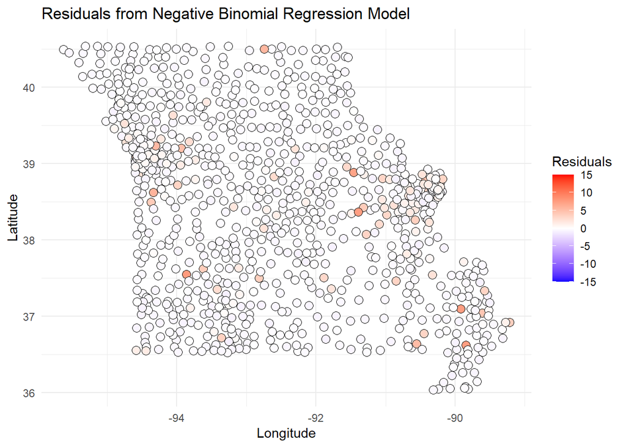

```r
map1
```

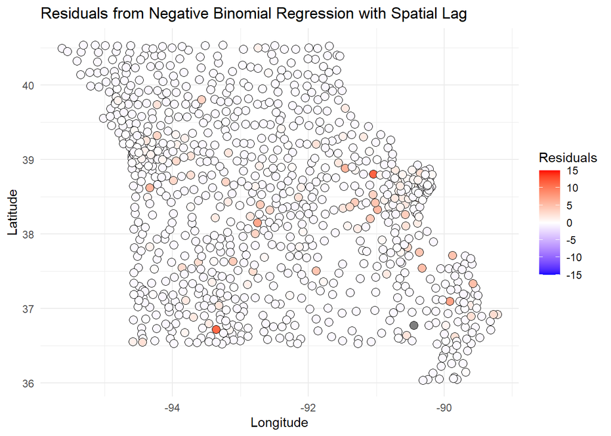

```r
map2
```

**Interpretation**:

### Model 4 - Spatial Negative Binomial Regresssion Model Stratified by Rural/Urban

#### 4.1 Stratifying the dataset into Urban and Rural

```r
# Inspect the rurality variable
table(mh_data2020_clean_sf$Rurality)
```

```
##
## Rural Urban
##   724   218
```

```r
# Convert to a factor if not already
mh_data2020_clean_sf$Rurality <- as.factor(mh_data2020_clean_sf$Rurality)

# Subset data for urban areas
urban_data <- subset(mh_data2020_clean_sf, Rurality == "Urban")

# Subset data for rural areas
rural_data <- subset(mh_data2020_clean_sf, Rurality == "Rural")
```

#### 4.2 Fitting the stratified model

```r
#Fit the Negative Binomial model with the spatial lag term to address the spatial] autocorrelation

urban_nb_model_with_spatial_lag <- glm.nb(
  mh_Requests ~ WalkabilityIndex + belowPovertyLevel_Percentage   + spatial_lag
     + Insured_Percentage +
    housingOccupancy_Percentage + weightedEducationScore + populationDensity,
  data = urban_data
)


#Fit the Negative Binomial model with the spatial lag term to address the spatial] autocorrelation

rural_nb_model_with_spatial_lag <- glm.nb(
  mh_Requests ~ WalkabilityIndex + belowPovertyLevel_Percentage   + spatial_lag +
    Insured_Percentage +
    housingOccupancy_Percentage + weightedEducationScore + populationDensity,
  data = rural_data
)



# Summaries of each model
summary(urban_nb_model_with_spatial_lag)
```

```
##
## Call:
## glm.nb(formula = mh_Requests ~ WalkabilityIndex + belowPovertyLevel_Percentage +
##     spatial_lag + Insured_Percentage + housingOccupancy_Percentage +
##     weightedEducationScore + populationDensity, data = urban_data,
##     init.theta = 0.6101255687, link = log)
##
## Coefficients:
##                                Estimate Std. Error z value Pr(>|z|)
## (Intercept)                  -6.228e+00  2.157e+00  -2.887 0.003888 **
## WalkabilityIndex              1.845e-01  4.200e-02   4.392 1.12e-05 ***
## belowPovertyLevel_Percentage  3.045e-02  1.286e-02   2.367 0.017932 *
## spatial_lag                   4.201e-02  1.264e-02   3.323 0.000889 ***
## Insured_Percentage            1.630e-02  2.276e-02   0.716 0.473790
## housingOccupancy_Percentage   4.940e-02  1.532e-02   3.225 0.001261 **
## weightedEducationScore       -2.420e-01  4.720e-01  -0.513 0.608158
## populationDensity             1.012e-04  7.325e-05   1.381 0.167241
## ---
## Signif. codes:  0 '***' 0.001 '**' 0.01 '*' 0.05 '.' 0.1 ' ' 1
##
## (Dispersion parameter for Negative Binomial(0.6101) family taken to be 1)
##
##     Null deviance: 419.96  on 217  degrees of freedom
## Residual deviance: 228.03  on 210  degrees of freedom
## AIC: 1113.7
##
## Number of Fisher Scoring iterations: 1
##
##
##               Theta:  0.6101
##           Std. Err.:  0.0832
##
##  2 x log-likelihood:  -1095.7150
```

```r
summary(rural_nb_model_with_spatial_lag)
```

```
##
## Call:
## glm.nb(formula = mh_Requests ~ WalkabilityIndex + belowPovertyLevel_Percentage +
##     spatial_lag + Insured_Percentage + housingOccupancy_Percentage +
##     weightedEducationScore + populationDensity, data = rural_data,
##     init.theta = 0.1744288016, link = log)
##
## Coefficients:
##                                Estimate Std. Error z value Pr(>|z|)
## (Intercept)                  -8.3052080  1.6609633  -5.000 5.73e-07 ***
## WalkabilityIndex              0.1606903  0.0841196   1.910 0.056100 .
## belowPovertyLevel_Percentage  0.0295729  0.0123429   2.396 0.016578 *
## spatial_lag                   0.0927089  0.0224009   4.139 3.49e-05 ***
## Insured_Percentage           -0.0100788  0.0152795  -0.660 0.509495
## housingOccupancy_Percentage   0.0356869  0.0096980   3.680 0.000233 ***
## weightedEducationScore        1.6283379  0.5079962   3.205 0.001349 **
## populationDensity             0.0001052  0.0002125   0.495 0.620729
## ---
## Signif. codes:  0 '***' 0.001 '**' 0.01 '*' 0.05 '.' 0.1 ' ' 1
##
## (Dispersion parameter for Negative Binomial(0.1744) family taken to be 1)
##
##     Null deviance: 605.66  on 723  degrees of freedom
## Residual deviance: 339.57  on 716  degrees of freedom
## AIC: 1251.9
##
## Number of Fisher Scoring iterations: 1
##
##
##               Theta:  0.1744
##           Std. Err.:  0.0239
##
##  2 x log-likelihood:  -1233.8740
```

```r
#Show Odds and CIs
tidy(urban_nb_model_with_spatial_lag, exponentiate = TRUE, conf.int = TRUE)
```

```
## # A tibble: 8 × 7
##   term                   estimate std.error statistic p.value conf.low conf.high
##   <chr>                     <dbl>     <dbl>     <dbl>   <dbl>    <dbl>     <dbl>
## 1 (Intercept)             0.00197 2.16         -2.89  3.89e-3  6.34e-6     0.534
## 2 WalkabilityIndex        1.20    0.0420        4.39  1.12e-5  1.11e+0     1.31
## 3 belowPovertyLevel_Per…  1.03    0.0129        2.37  1.79e-2  9.97e-1     1.07
## 4 spatial_lag             1.04    0.0126        3.32  8.89e-4  1.02e+0     1.07
## 5 Insured_Percentage      1.02    0.0228        0.716 4.74e-1  9.56e-1     1.08
## 6 housingOccupancy_Perc…  1.05    0.0153        3.22  1.26e-3  1.02e+0     1.09
## 7 weightedEducationScore  0.785   0.472        -0.513 6.08e-1  2.83e-1     2.21
## 8 populationDensity       1.00    0.0000733     1.38  1.67e-1  1.00e+0     1.00
```

```r
#Show Odds and CIs
tidy(rural_nb_model_with_spatial_lag, exponentiate = TRUE, conf.int = TRUE)
```

```
## # A tibble: 8 × 7
##   term                   estimate std.error statistic p.value conf.low conf.high
##   <chr>                     <dbl>     <dbl>     <dbl>   <dbl>    <dbl>     <dbl>
## 1 (Intercept)            0.000247  1.66        -5.00  5.73e-7  4.46e-6    0.0109
## 2 WalkabilityIndex       1.17      0.0841       1.91  5.61e-2  9.91e-1    1.40
## 3 belowPovertyLevel_Per… 1.03      0.0123       2.40  1.66e-2  9.99e-1    1.06
## 4 spatial_lag            1.10      0.0224       4.14  3.49e-5  1.04e+0    1.18
## 5 Insured_Percentage     0.990     0.0153      -0.660 5.09e-1  9.52e-1    1.03
## 6 housingOccupancy_Perc… 1.04      0.00970      3.68  2.33e-4  1.02e+0    1.06
## 7 weightedEducationScore 5.10      0.508        3.21  1.35e-3  1.64e+0   17.2
## 8 populationDensity      1.00      0.000213     0.495 6.21e-1  1.00e+0    1.00
```

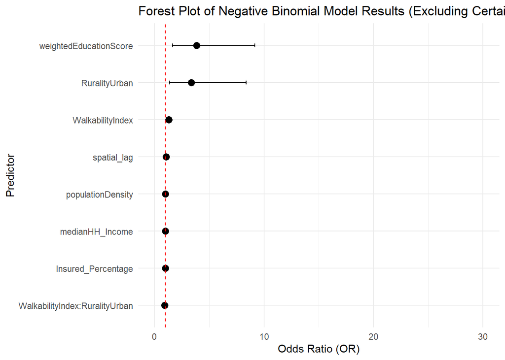

```r
# Extract model results as a tidy dataframe
results <- tidy(nb_model_with_spatial_lag, exponentiate = TRUE, conf.int = TRUE)

# Filter out the intercept and the two variables you don't want to include
results_forest <- results %>%
  filter(term != "(Intercept)" &
         term != "housingOccupancy_Percentage" &
         term != "belowPovertyLevel_Percentage")

# Create the forest plot
ggplot(results_forest, aes(x = reorder(term, estimate), y = estimate)) +
  geom_point(size = 3) +
  geom_errorbar(aes(ymin = conf.low, ymax = conf.high), width = 0.1) +
  coord_flip() +
  xlab("Predictor") +
  ylab("Odds Ratio (OR)") +
  ggtitle("Forest Plot of Negative Binomial Model Results (Excluding Certain Predictors)") +
  geom_hline(yintercept = 1, linetype = "dashed", color = "red") +
    scale_y_continuous(limits = c(0, 30)) +  # Set y-axis range from 0 to 30
  theme_minimal()
```

## Results

```r
# Extract tidy results for urban and rural models
urban_results <- tidy(urban_nb_model_with_spatial_lag, exponentiate = TRUE, conf.int = TRUE)
rural_results <- tidy(rural_nb_model_with_spatial_lag, exponentiate = TRUE, conf.int = TRUE)

# Format the Urban Table
formatted_urban <- urban_results %>%
  mutate(
    Predictor = term,
    `Estimate (β)` = round(estimate, 3),
    `Std. Error` = round(std.error, 3),
    `z-value` = round(statistic, 3),
    `p-value` = round(p.value, 3),
    `IRR (Exp(β))` = round(estimate, 3),
    `95% CI (IRR)` = paste0("(", round(conf.low, 3), ", ", round(conf.high, 3), ")")
  ) %>%
  dplyr::select(Predictor, `Estimate (β)`, `Std. Error`, `z-value`, `p-value`, `IRR (Exp(β))`, `95% CI (IRR)`)

# Format the Rural Table
formatted_rural <- rural_results %>%
  mutate(
    Predictor = term,
    `Estimate (β)` = round(estimate, 3),
    `Std. Error` = round(std.error, 3),
    `z-value` = round(statistic, 3),
    `p-value` = round(p.value, 3),
    `IRR (Exp(β))` = round(estimate, 3),
    `95% CI (IRR)` = paste0("(", round(conf.low, 3), ", ", round(conf.high, 3), ")")
  ) %>%
  dplyr::select(Predictor, `Estimate (β)`, `Std. Error`, `z-value`, `p-value`, `IRR (Exp(β))`, `95% CI (IRR)`)

# Display Urban Results Table
formatted_urban %>%
  kbl(caption = "Urban NB Model Results") %>%
  kable_styling(full_width = FALSE, bootstrap_options = c("striped", "hover", "condensed"))
```

Urban NB Model Results

[output not shown]

```r
# Display Rural Results Table
formatted_rural %>%
  kbl(caption = "Rural NB Model Results") %>%
  kable_styling(full_width = FALSE, bootstrap_options = c("striped", "hover", "condensed"))
```

Rural NB Model Results

[output not shown]